# High Priority Weather Events based on Fatalities, Injuries, and Property Damage

Michael Wood

January 30, 2018

# Summary of Findings

This analysis considers the database of weather events and their related public health and economic effects. By first breaking down the data into the leading weather causes of fatalities, injuries, and property damage, a pattern begins to emerge as to the primary concerns a regional government should consider. Primary causes of fatalities were determined to be tornados, heat, flash floods, lightning, thunderstorm winds. Most commonly, injuries resulted from tornados, thunderstorm winds, floods, heat, and lightning. Property damage was most expensive following tornados, floods, thunderstorm winds, hail, and lightning. Both public health and economic concerns should be addressed by considering tornados, flooding, lightning, and thunderstorm winds. This indicates public health would be improved by addressing the concerns of high heat, while addressing hail would have a greater impact on property damage.

## Knitr Configuration

```r
knitr::opts_chunk$set(echo = TRUE)
```

## Data Processing

```r
#!/usr/bin/env Rscript

library(ggplot2)

# Set fileURL and download data if necessary
fileURL <- ""
fileDL <- "repdata_data_StormData.csv.bz2"
if(!file.exists(fileDL)){
        download.file(fileURL, destfile=fileDL, method="curl")
}
```

## Read in data

```r
# Read in data from csv file
csvData <- read.csv(fileDL)

# Summation of Fatalities by Event Type
fatalByEvt <- as.data.frame(
  tapply(csvData$FATALITIES, csvData$EVTYPE, FUN=sum))
colnames(fatalByEvt) <- c("Fatalities")
# Create data frame while removing Events with ZERO fatalities
FBE.NoZero <- as.data.frame(fatalByEvt[fatalByEvt$Fatalities!=0,])
colnames(FBE.NoZero) <- c("Fatalities")

# Summation of Injuries by Event Type
injuryByEvt <- as.data.frame(
  tapply(csvData$INJURIES, csvData$EVTYPE, FUN=sum))
colnames(injuryByEvt) <- c("Injuries")
# Create data frame while removing Events with ZERO injuries
IBE.NoZero <- as.data.frame(injuryByEvt[injuryByEvt$Injuries!=0,])
colnames(IBE.NoZero) <- c("Injuries")

# Summation of Property Damage by Event Type
propDmgByEvt <- as.data.frame(
  tapply(csvData$PROPDMG, csvData$EVTYPE, FUN=sum))
colnames(propDmgByEvt) <- c("Dollars")
# Create data frame while removing Events with ZERO property damage
PBE.NoZero <- as.data.frame(propDmgByEvt[propDmgByEvt$Dollars!=0,])
colnames(PBE.NoZero) <- c("Dollars")

# Summation of Crop Damage by Event Type
cropDmgByEvt <- as.data.frame(
  tapply(csvData$CROPDMG, csvData$EVTYPE, FUN=sum))
colnames(cropDmgByEvt) <- c("Count")
# Create data frame while removing Events with ZERO crop damage
CBE.NoZero <- as.data.frame(cropDmgByEvt[cropDmgByEvt$Count!=0,])
colnames(CBE.NoZero) <- c("Count")
```

## Fatalities

```r
qtilesFBE <- quantile(FBE.NoZero$Fatalities, probs = seq(0, 1, 0.1))
topFatal <- FBE.NoZero[FBE.NoZero$Fatalities>qtilesFBE[10],]
totalFatal <- sum(fatalByEvt$Fatalities)
pctTotFatal <- round(sum(topFatal)/totalFatal*100, 2)

fatal.df <- as.data.frame(topFatal)
fatal.df <- cbind(fatal.df, row.names(fatal.df))
colnames(fatal.df) <- c("Fatalities", "Events")
```

## Injuries

```r
qtilesIBE <- quantile(IBE.NoZero$Injuries, probs = seq(0, 1, 0.1))
topInjury <- IBE.NoZero[IBE.NoZero$Injuries>qtilesIBE[10],]
totalInjury <- sum(injuryByEvt$Injuries)
pctTotInjury <- round(sum(topInjury)/totalInjury*100, 2)

injury.df <- as.data.frame(topInjury)
injury.df <- cbind(injury.df, row.names(injury.df))
colnames(injury.df) <- c("Injuries", "Events")
```

## Property Damage

```r
qtilesPBE <- quantile(PBE.NoZero$Dollars, probs = seq(0, 1, 0.1))
topPropDmg <- PBE.NoZero[PBE.NoZero$Dollars>qtilesPBE[10],]
totalPropDmg <- sum(propDmgByEvt$Dollars)
pctTotPropDmg <- round(sum(topPropDmg)/totalPropDmg*100, 2)

propDmg.df <- as.data.frame(topPropDmg)
propDmg.df <- cbind(propDmg.df, row.names(propDmg.df))
colnames(propDmg.df) <- c("Dollars", "Events")
```

## Crop Damage

```r
qtilesCBE <- quantile(CBE.NoZero$Count, probs = seq(0, 1, 0.1))
topCropDmg <- CBE.NoZero[CBE.NoZero$Count>qtilesCBE[10],]
totalCropDmg <- sum(cropDmgByEvt$Count)
```

# Results

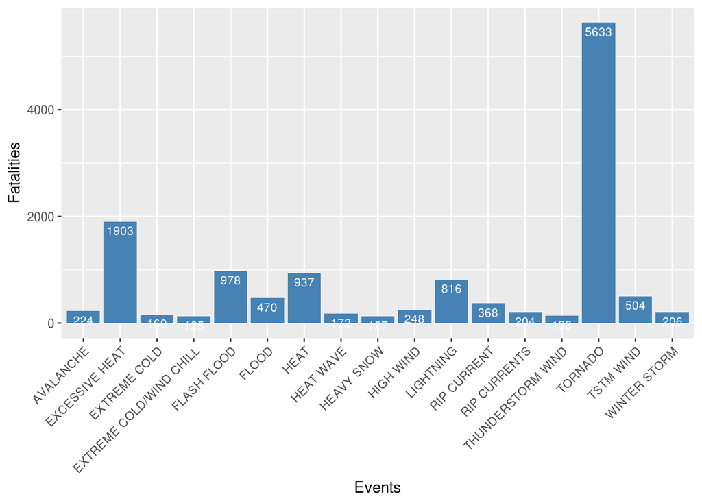

```r
#qplot(topFatal, row.names(topFatal))

ggplot(data=fatal.df, aes(x=Events, y=Fatalities)) +
    geom_bar(stat="identity", fill="steelblue")+
    geom_text(aes(label=Fatalities), vjust=1.6, color="white", size=3)+
    theme(axis.text.x = element_text(angle = 45, hjust = 1))
```

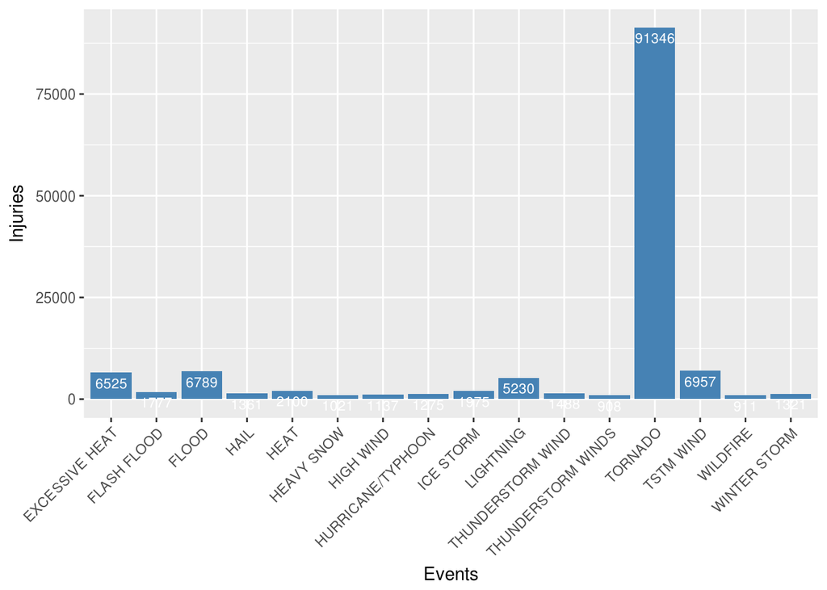

```r
#qplot(topInjury, row.names(topInjury))

ggplot(data=injury.df, aes(x=Events, y=Injuries)) +
    geom_bar(stat="identity", fill="steelblue")+
    geom_text(aes(label=Injuries), vjust=1.6, color="white", size=3)+
    theme(axis.text.x = element_text(angle = 45, hjust = 1))
```

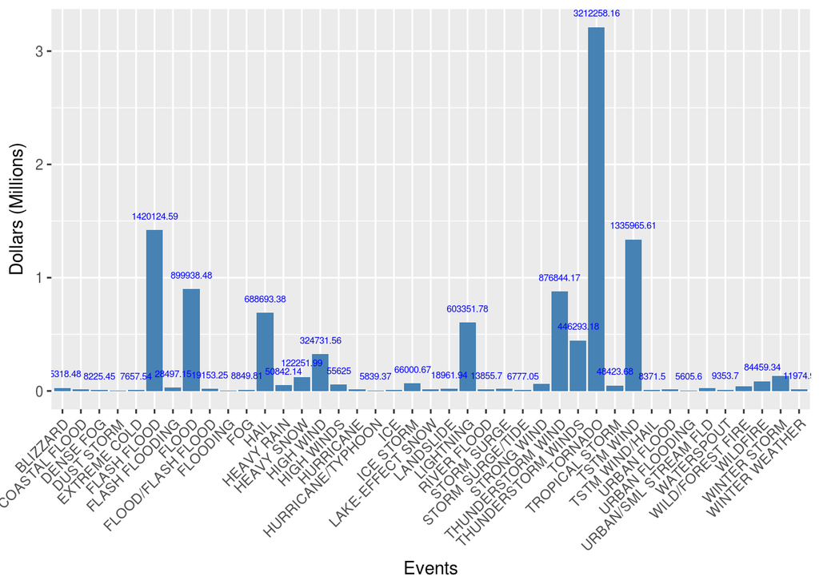

```r
#qplot(topPropDmg, row.names(topPropDmg))

ggplot(data=propDmg.df, aes(x=Events, y=Dollars/1000000)) +
    geom_bar(stat="identity", fill="steelblue")+
    geom_text(aes(label=Dollars), vjust=-1.6, color="blue", size=2, check_overlap = TRUE)+
    theme(axis.text.x = element_text(angle = 45, hjust = 1)) + ylab("Dollars (Millions)")
```